# Stat 3301: Homework 6

Due by date and time specified on Carmen

Nathan Johnson.9254

Setup:

```r
knitr::opts_chunk$set(echo = TRUE)
library(alr4)
library(tidyverse)
```

#### Instructions

- Replace “FirstName LastName (name.n)” above with your information.
- Provide your solutions below in the spaces marked “Solution:”.
- Include any R code that you use to answer the questions; if a numeric answer is required, show how you calculated it in R. I have set the global option `echo = TRUE` to make sure the R code is displayed.
- Knit this document to HTML and upload both the HTML file and your completed Rmd file to Carmen
- Make sure your solutions are clean and easy-to-read by
  - formatting all plots to be appropriately sized, with appropriate axis labels.
  - only including R code that is necessary to answer the questions below.
  - only including R output that is necessary to answer the questions below (avoiding lengthy output).
  - providing short written answers explaining your work, and writing in complete sentences.
- Data files mentioned below are from the `alr4` package unless specified otherwise.

#### Concepts & Application

In this assignment, you will

- plot pairwise relationships between three variables.
- fit a multiple linear regression model in R.
- gain experience with several matrix operations in R.
- calculate a “hat value” (leverage) for a case.
- use plots of standardized residuals to assess model fit.

#### Question 1

This question is concerned with the following variables from the NBA data set for **guards** only:

| Variable | Description |
| --- | --- |
| `wt` | weight of player (guard) in pounds |
| `ht` | height of player (guard) in inches |
| `age` | age of player (guard) in years |

We will be interested in using `ht` and `age` jointly to predict `wt` for **guards** (ignoring the other positions for now).

1. Make a scatterplot matrix for the variables `ht`, `age` and `wt`. Use the plots to describe the pairwise relationships between the variables.
2. Use `R` to fit a multiple linear regression model with mean function $E(\mathtt{wt} \mid \mathtt{ht}, \mathtt{age}) = \beta_0 + \beta_1 \mathtt{ht} + \beta_2 \mathtt{age}$ and variance function $\mbox{Var}(\mathtt{wt} \mid \mathtt{ht}, \mathtt{age}) = \sigma^2$. Use the `summary` function to display `R`’s standard summary of the fitted model.
3. Report the numeric values of the parameter estimates $\hat{\beta}_j$, $j = 0, 1, 2$, and $\hat{\sigma}^2$.
4. Report the numeric value of the degrees of freedom associated with the fitted model. Say what formula you use to calculate this value.
5. Use R to compute and display the 3x3 matrix $X^T X$, where *X* is the $202 \times 3$ matrix used to fit the regression model.
6. Use R to compute and report the 3x3 matrix $(X^TX)^{-1}$.
7. Nate Robinson should be the first case in the data set ($i = 1$). Compute and report the leverage $h_{11}$ for Nate Robinson under this MLR model in two ways: (i) using the `hatvalues` function and (ii) by computing the **H** matrix directly and reporting the first diagonal element.
8. Make three plots of the standardized residuals $r_i$: (i) $r_i$ versus the fitted values $\hat{y}_i$, (ii) $r_i$ versus `ht` and (iii) $r_i$ versus `age`. Do the plots suggest any problems with our assumptions about the mean and variance functions?

(Note: you will notice some diagonal “stripes” in the plot of residuals versus fitted values. These are due to the fact that the weights are rounded to the nearest pound, and are **not** a cause for concern.)

##### Solution to Question 1

Your answers go here.

```r
library(readr)
nba = read.csv('nbahtwt.csv')
nbaG = nba %>% filter(pos=="G")
```

*Part a:*

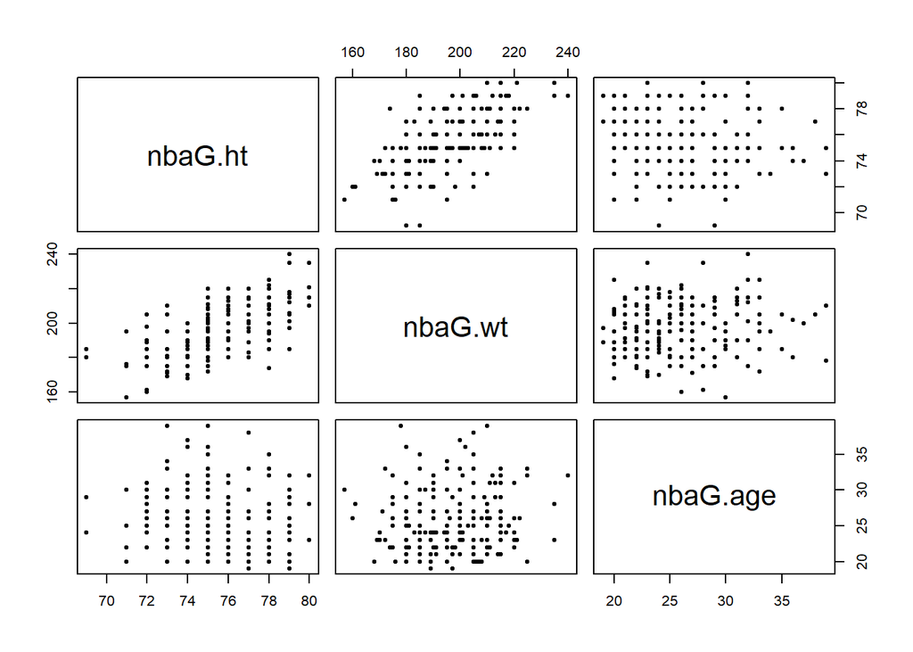

```r
df = data.frame(nbaG$ht, nbaG$wt, nbaG$age)
plot(df, pch = 20)
```

To keep it simple, the bottom left plots will be used.

There is a positive correlation between height and weight. As height increases, so does weight. The relationship between height and age is hard to see visually. There may be a weak and slightly negative correlation. The relationship between weight and age also seems inconclusive.

*Part b:*

```r
library(scatterplot3d)
plot = scatterplot3d(x = nbaG$ht, y = nbaG$age, z = nbaG$wt, xlab = "Height (in)", ylab = "Age", zlab = "Weight (lbs)")
nbaG.lm = lm(wt ~ ht + age, data = nbaG)
summary(nbaG.lm)
```

```
##
## Call:
## lm(formula = wt ~ ht + age, data = nbaG)
##
## Residuals:
##     Min      1Q  Median      3Q     Max
## -31.453  -7.713  -1.310   8.908  26.993
##
## Coefficients:
##              Estimate Std. Error t value Pr(>|t|)
## (Intercept) -148.8194    30.2457  -4.920 1.81e-06 ***
## ht             4.4250     0.3866  11.445  < 2e-16 ***
## age            0.4146     0.2001   2.072   0.0396 *
## ---
## Signif. codes:  0 '***' 0.001 '**' 0.01 '*' 0.05 '.' 0.1 ' ' 1
##
## Residual standard error: 11.96 on 199 degrees of freedom
## Multiple R-squared:  0.3982, Adjusted R-squared:  0.3922
## F-statistic: 65.85 on 2 and 199 DF,  p-value: < 2.2e-16
```

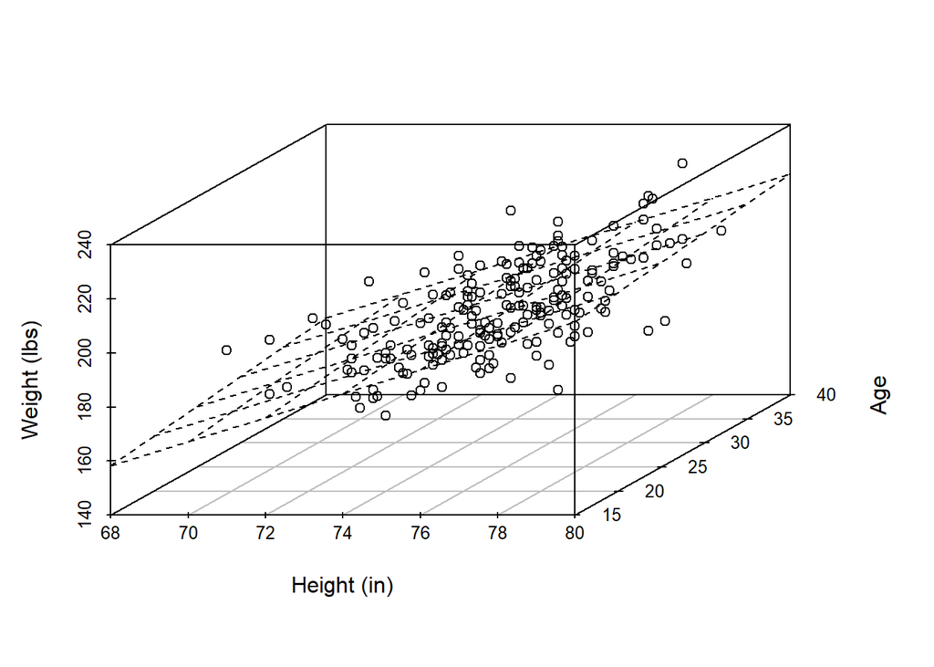

```r
plot$plane3d(nbaG.lm)
```

$E(wt|ht,age) = -148.8194 + 4.4250 * ht + 0.4146 * age$

$Var(wt|ht,age) = 142.9714$

*Part c:*

```r
Y = matrix(nbaG$wt, ncol = 1)
X = cbind(rep(1, length(Y)), nbaG$ht, nbaG$age)
vars = 2
vals = solve(t(X) %*% X) %*% t(X) %*% Y
B0 = vals[1,1]
B1 = vals[2,1]
B2 = vals[3,1]
B0
```

```
## [1] -148.8194
```

```r
B1
```

```
## [1] 4.425022
```

```r
B2
```

```
## [1] 0.4145856
```

```r
yhat = B0 + B1*X[,2] + B2*X[,3]
s2 = t(Y - yhat) %*% (Y - (B0 + B1*X[,2] + B2*X[,3]))/(length(X[,1]) - (vars + 1))
s2
```

```
##          [,1]
## [1,] 142.9714
```

$\hat{\beta}_0 = -148.8194$, $\hat{\beta}_1 = 4.4250$, $\hat{\beta}_2 = 0.4146$, $\hat{\sigma}^2 = 142.9714$.

*Part d:* $df = n - p -1 = 202 - 2 - 1 = 199$. I used the degrees of freedom for multiple linear regression which is: length of X - number of predictor variables - 1.

*Part e:*

```r
XTX = t(X) %*% X
XTX
```

```
##       [,1]    [,2]   [,3]
## [1,]   202   15274   5219
## [2,] 15274 1155894 394426
## [3,]  5219  394426 138455
```

*Part f:*

```r
r = 3
invXTX = solve(t(X) %*% X, diag(r))
invXTX
```

```
##             [,1]          [,2]          [,3]
## [1,]  6.39849508 -8.056762e-02 -1.167008e-02
## [2,] -0.08056762  1.045471e-03  5.865648e-05
## [3,] -0.01167008  5.865648e-05  2.800226e-04
```

*Part g:*

```r
h11hat = head(hatvalues(nbaG.lm), 1)
h11hat
```

```
##          1
## 0.05103045
```

```r
H = X %*% invXTX %*% t(X)
H[1,1]
```

```
## [1] 0.05103045
```

As seen, $h_{11} = 0.05103$

*Part h:*

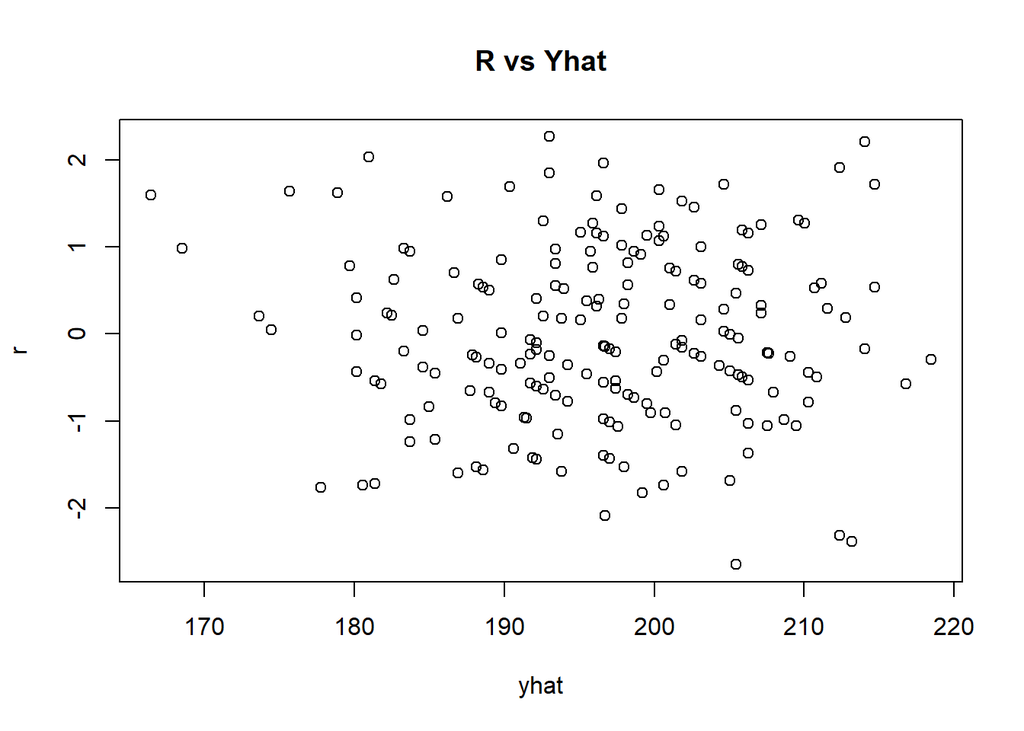

```r
r = (Y - yhat)/((sqrt(s2[1,1]))*sqrt(1-diag(H)))
plot(yhat, r, ylab = "r", main = "R vs Yhat")
```

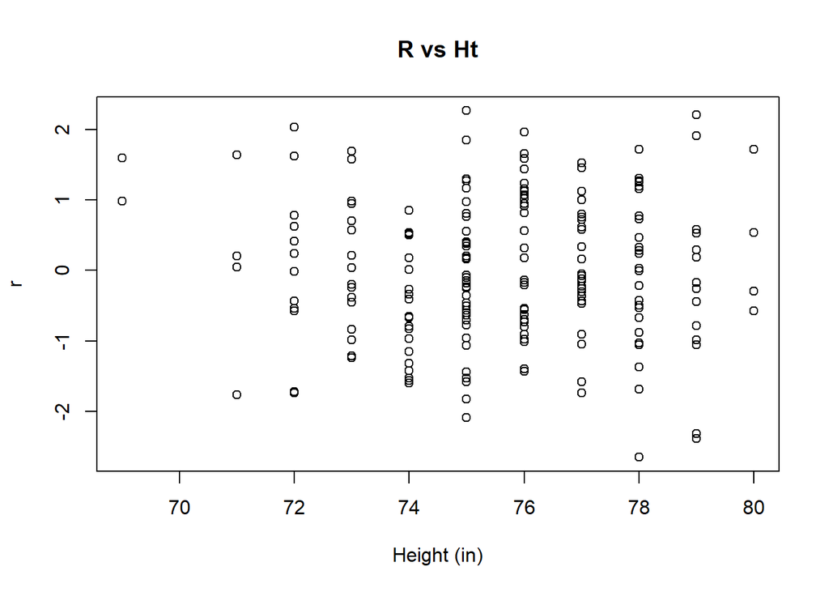

```r
plot(nbaG$ht, r, ylab = "r", xlab = "Height (in)", main = "R vs Ht")
```

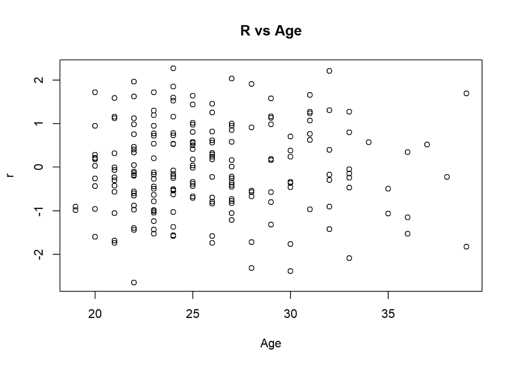

```r
plot(nbaG$age, r, ylab = "r", xlab = "Age", main = "R vs Age")
```

Each of the graphs roughly show no correlation, constant variance, and the mean hovering around 0 which means the plots do not suggest any problems with our assumptions about the mean and variance functions.